# Bisphosphonates adverse events meta-analysis: comparing healthy and cancer patients

2019-12-11

# Bisphosphonate effects on events compared between cancer and healthy patients.

Just two studies of bisphosphonates for preventing osteoperosis in “healthy” women without cancer: FIT and Horizon.

- HORIZON: two papers reported on the same population, one reporting acute events following the start of treatment, and one with longer follow-up. It’s unclear whether some of the same events are repeated between the two reports.
- FIT: two papers, one reporting the full trial population and the other reporting a subgroup. The only events reported were abdominal pain, oesophagitis, dyspepsia, gastrointestinal (unspecified) and nausea.

The table below compares the odds ratios from the network meta-analysis of bisphosphonates in women with cancer with the equivalent odds ratios from a simple meta-analysis of HORIZON and FIT, for the events that are significant in the cancer analysis and also reported in HORIZON and FIT.

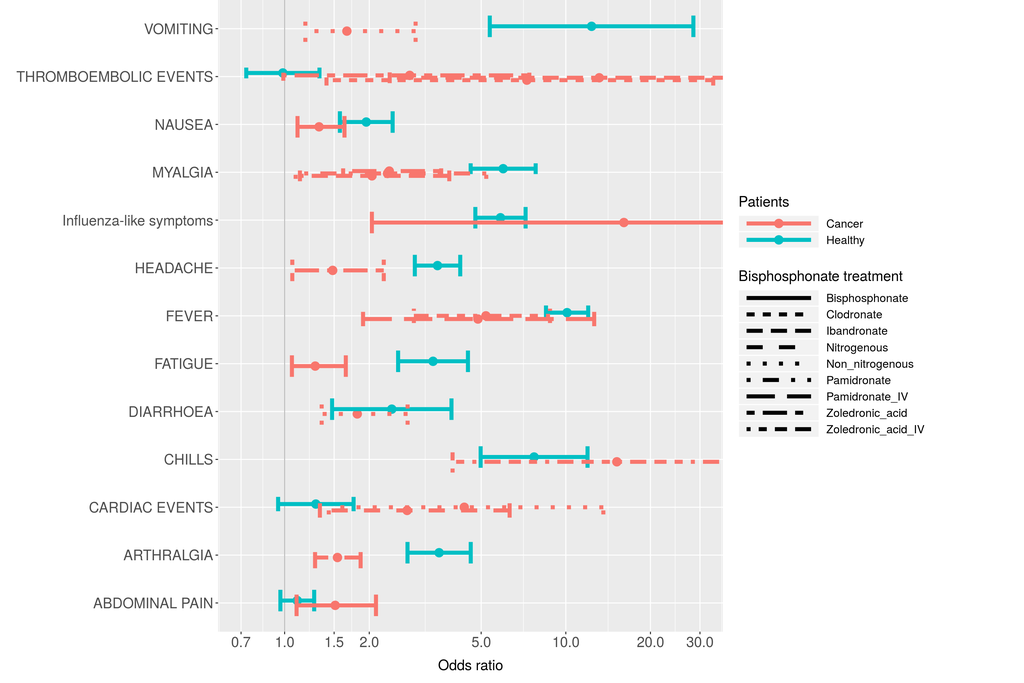

|  |  | Treatment (cancer NMA) | OR (Cancer, NMA) | Treatment (healthy MA) | OR (healthy MA) |
| --- | --- | --- | --- | --- | --- |
| MYALGIA |  |  |  |  |  |
|  | MYALGIA | Ibandronate | 2.04 (1.13, 3.85) | Bisphosphonate | 5.99 (4.59, 7.81) |
|  | MYALGIA | Pamidronate | 2.32 (1.09, 5.21) | Bisphosphonate | 5.99 (4.59, 7.81) |
|  | MYALGIA | Zoledronic_acid | 2.36 (1.61, 3.6) | Bisphosphonate | 5.99 (4.59, 7.81) |
| OTHERS |  |  |  |  |  |
|  | ABDOMINAL PAIN | Bisphosphonate | 1.51 (1.1, 2.11) | Bisphosphonate | 1.11 (0.97, 1.27) |
|  | ARTHRALGIA | Nitrogenous | 1.54 (1.28, 1.86) | Bisphosphonate | 3.54 (2.74, 4.59) |
|  | CARDIAC EVENTS | Nitrogenous | 2.73 (1.33, 6.31) | Bisphosphonate | 1.29 (0.95, 1.76) |
|  | CARDIAC EVENTS | Non_nitrogenous | 4.35 (1.44, 13.6) | Bisphosphonate | 1.29 (0.95, 1.76) |
|  | CHILLS | Zoledronic_acid_IV | 15.19 (3.96, 94.86) | Bisphosphonate | 7.71 (4.98, 11.95) |
|  | DIARRHOEA | Non_nitrogenous | 1.81 (1.35, 2.74) | Bisphosphonate | 2.41 (1.48, 3.92) |
|  | FATIGUE | Bisphosphonate | 1.28 (1.06, 1.65) | Bisphosphonate | 3.37 (2.53, 4.49) |
|  | FEVER | Pamidronate_IV | 4.87 (1.9, 12.62) | Bisphosphonate | 10.11 (8.5, 12.01) |
|  | FEVER | Zoledronic_acid_IV | 5.2 (2.88, 8.79) | Bisphosphonate | 10.11 (8.5, 12.01) |
|  | HEADACHE | Zoledronic_acid | 1.48 (1.06, 2.25) | Bisphosphonate | 3.5 (2.9, 4.21) |
|  | Influenza-like symptoms | Bisphosphonate | 16.09 (2.04, 207.85) | Bisphosphonate | 5.86 (4.77, 7.19) |
|  | NAUSEA | Bisphosphonate | 1.33 (1.11, 1.63) | Bisphosphonate | 1.95 (1.57, 2.42) |
|  | THROMBOEMBOLIC EVENTS | Clodronate | 7.27 (1.41, 33.44) | Bisphosphonate | 0.99 (0.73, 1.33) |
|  | THROMBOEMBOLIC EVENTS | Ibandronate | 13.15 (2.36, 68.93) | Bisphosphonate | 0.99 (0.73, 1.33) |
|  | THROMBOEMBOLIC EVENTS | Zoledronic_acid | 2.79 (0.99, 7.42) | Bisphosphonate | 0.99 (0.73, 1.33) |
|  | VOMITING | Non_nitrogenous | 1.67 (1.18, 2.92) | Bisphosphonate | 12.35 (5.37, 28.42) |

Events deemed significant in a fixed effects meta analysis of HORIZON/FIT, using same criterion as in the main analysis: statistically significant OR > 1.5 or risk difference > 0.02.

|  | Odds ratio | Risk difference |
| --- | --- | --- |
| NAUSEA | 1.95 (1.57, 2.42) | 0.01 (0.01, 0.01) |
| ARTHRALGIA | 3.54 (2.74, 4.59) | 0.02 (0.01, 0.02) |
| FEVER | 10.11 (8.5, 12.01) | 0.1 (0.1, 0.11) |
| HEADACHE | 3.5 (2.9, 4.21) | 0.03 (0.03, 0.04) |
| Influenza-like symptoms | 5.86 (4.77, 7.19) | 0.05 (0.04, 0.05) |
| MYALGIA | 5.99 (4.59, 7.81) | 0.03 (0.02, 0.03) |
| CHILLS | 7.71 (4.98, 11.95) | 0.01 (0.01, 0.02) |
| DEHYDRATION | 23.01 (1.36, 390.54) | 0 (0, 0) |
| DIARRHOEA | 2.41 (1.48, 3.92) | 0 (0, 0) |
| DIZZINESS | 1.89 (1.28, 2.78) | 0 (0, 0.01) |
| FATIGUE | 3.37 (2.53, 4.49) | 0.01 (0.01, 0.02) |
| HOT FLUSHES | 2.7 (1.31, 5.6) | 0 (0, 0) |
| LOSS OF APPETITE | 6.48 (2.92, 14.38) | 0 (0, 0) |
| MUSCULOSKELETAL PAIN/EVENT | 4.97 (4.19, 5.88) | 0.05 (0.05, 0.06) |
| Nasopharyngitis | 3.4 (1.25, 9.23) | 0 (0, 0) |
| OEDEMA | 4.5 (1.52, 13.32) | 0 (0, 0) |
| OTHER EYE DISORDERS | 11.03 (2.59, 46.93) | 0 (0, 0) |
| VOMITING | 12.35 (5.37, 28.42) | 0.01 (0, 0.01) |

The study-specific odds ratios underlying these results are shown below.

For each event, the odds ratios from HORIZON and FIT are not surprising given the variability between studies.

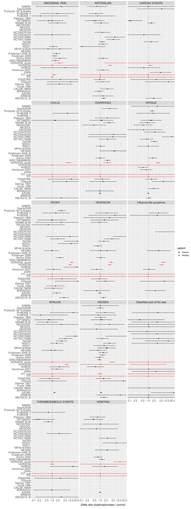